# Data appendix on global rioting dynamics

Jan 1, 0001 2 min read theory & empirics

This post serves as a short appendix for a forthcoming, online article on the cross-national historical dynamics of rioting.

Here is the citation for the dataset. The event data is based on news reports.

> Banks, Arthur S., and Kenneth A. Wilson. Cross-National Time-Series Data Archive. Jerusalem, Israel: Databanks International, 2017. https://www.cntsdata.com.

A common problem with cross-national historical data in political science is that countries enter and exit the international system of states. So global averages could potentially be misleading, especially if newer states are for some reason more or less conducive to rioting. For the main article, I report from the more general and complete sample of countries, but I also checked for this possible problem empirically. It turns out the story does not change substantially, whether you allow or disallow states to exit/enter the sample.

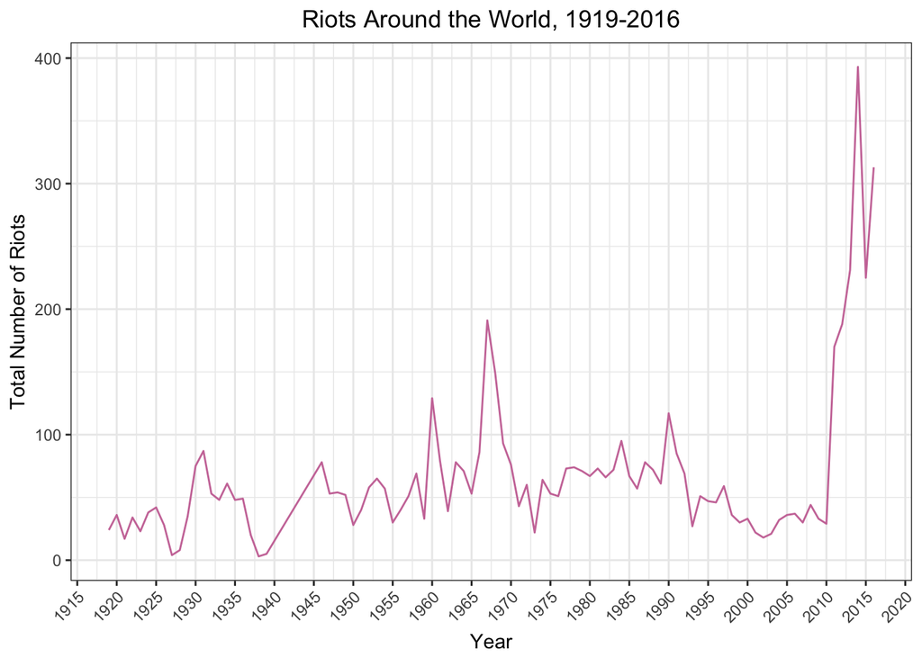

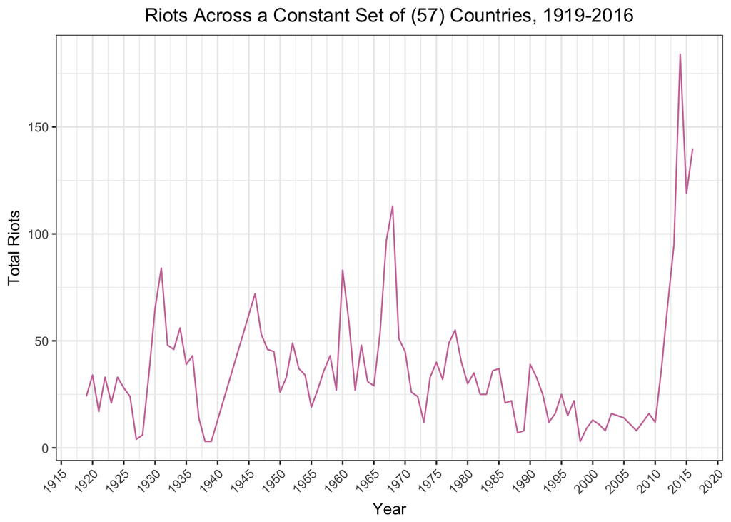

The 57 countries in the sample from 1919 to 2016 are:

Afghanistan, Albania, Argentina, Australia, Austria, Belgium, Bolivia, Brazil, Bulgaria, Canada, Chile, Colombia, Costa Rica, Cuba, Denmark, Dominican Republic, Ecuador, El Salvador, Estonia, Finland, France, Germany, Greece, Guatemala, Haiti, Honduras, Hungary, Iran, Italy, Japan, Latvia, Liberia, Lithuania, Luxembourg, Mexico, Nepal, Netherlands, New Zealand, Nicaragua, Norway, Panama, Paraguay, Peru, Poland, Portugal, Romania, Saudi Arabia, South Africa, Spain, Sweden, Switzerland, Thailand, Turkey, United Kingdom, United States, Uruguay, Venezuela

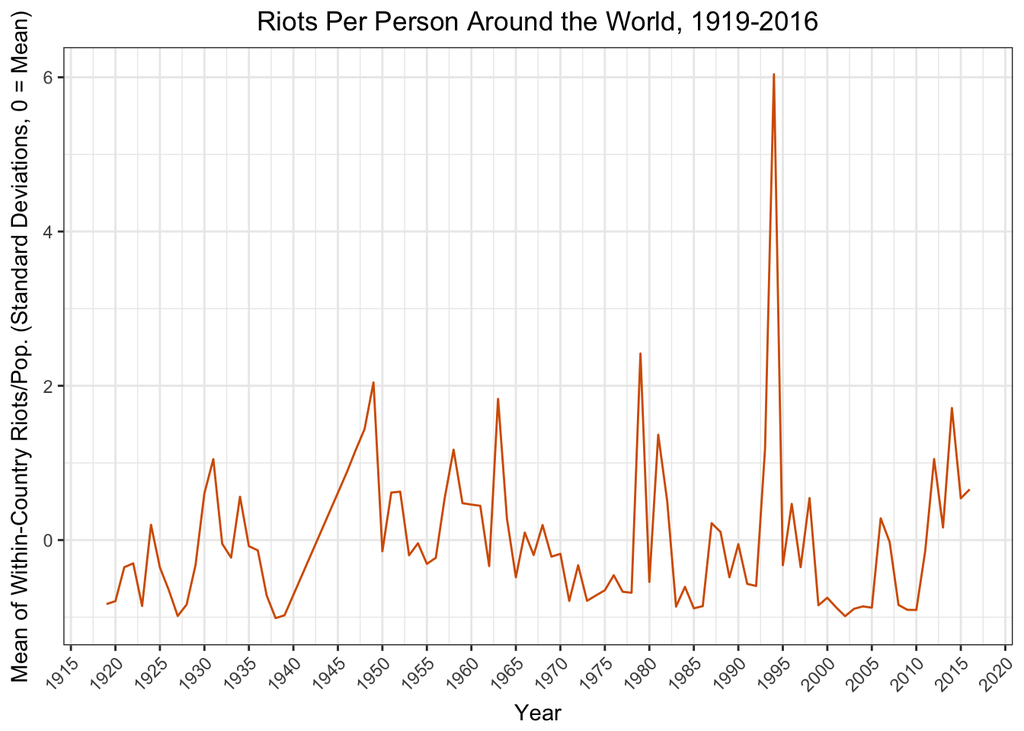

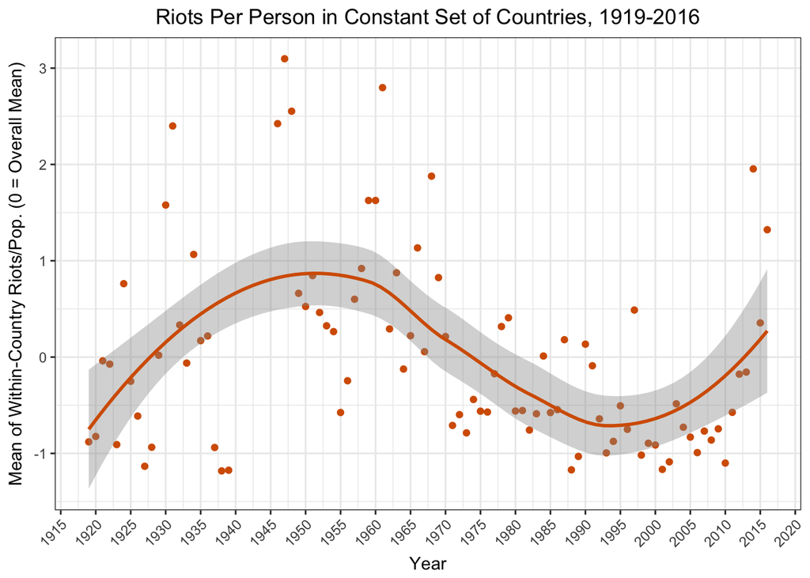

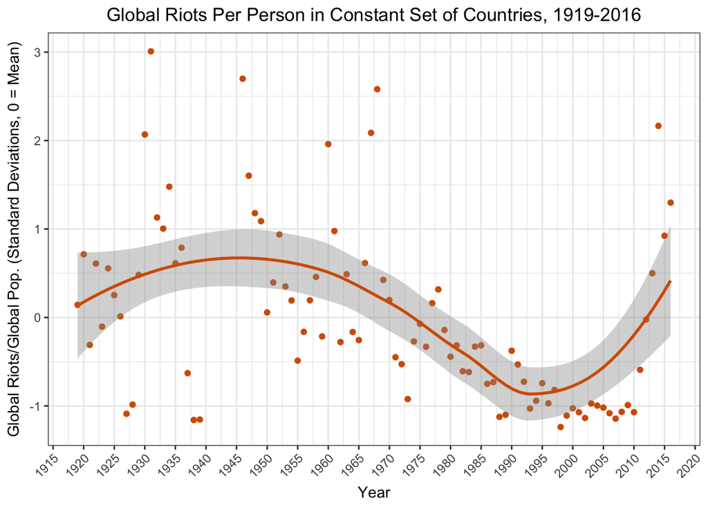

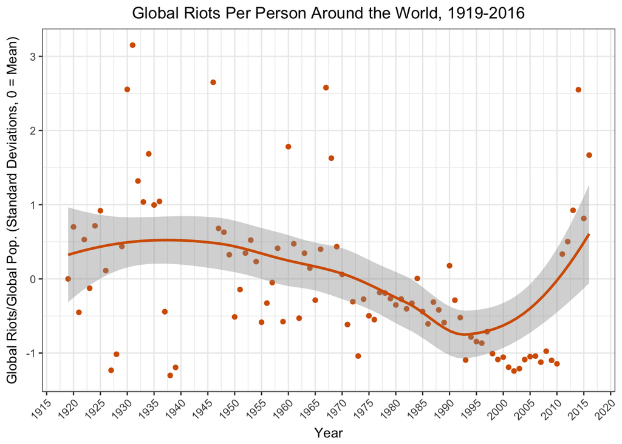

The global mean of country-level riots per person is not a good measure because it’s highly sensitive to riots in small countries. For instance, consider the large spike in 1994. The one instance of highest rioting per person, at country-level, was Saint Kitts and Nevis in 1994. There were prison riots and a jailbreak that year ([Britannica](https://www.britannica.com/place/Saint-Kitts-and-Nevis-Year-In-Review-1994)). The three riots that year constitute a high proportion of the population rioting, for the simple reason that the the country has a small population (only 42,000 at the time).

academic research data pacification radical politics

### Related

- Inequality and the Pacification of Militant Protest in the United States, 1919-2012
- The Alt-Right is not all Right: On the ideology of Kekistan
- Who’s afraid of free speech in the United States?
- The moral foundations of social justice warriors
- Are Americans becoming more conservative or liberal (right or left)?

[comments powered by Disqus](https://disqus.com)